# Tree Models Exercise

## 10.7 Waterfall Plot: Explaining One Prediction

Waterfall plots decompose a single prediction into its SHAP contributions — useful for explaining to a field scientist *why* the model predicted a particular value at a specific pedon location.

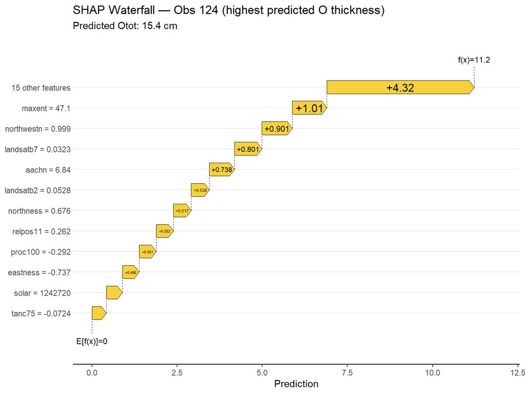

```r
# ── Use shapviz for polished single-observation plots ──────────────────────
sv <- shapviz(
  object = shap_vals,          # matrix of SHAP values
  X      = X_mat               # original feature values (for display)
)

# Find the observation with the highest predicted O horizon (most interesting)
best_obs  <- which.max(rf_shap$predictions)
worst_obs <- which.min(rf_shap$predictions)

# Waterfall for the thickest predicted O horizon
sv_waterfall(sv, row_id = best_obs, max_display = 12) +
  labs(title = paste0("SHAP Waterfall — Obs ", best_obs,
                      " (highest predicted O thickness)"),
       subtitle = paste0("Predicted Otot: ",
                         round(rf_shap$predictions[best_obs], 1),
                         " cm"))
```

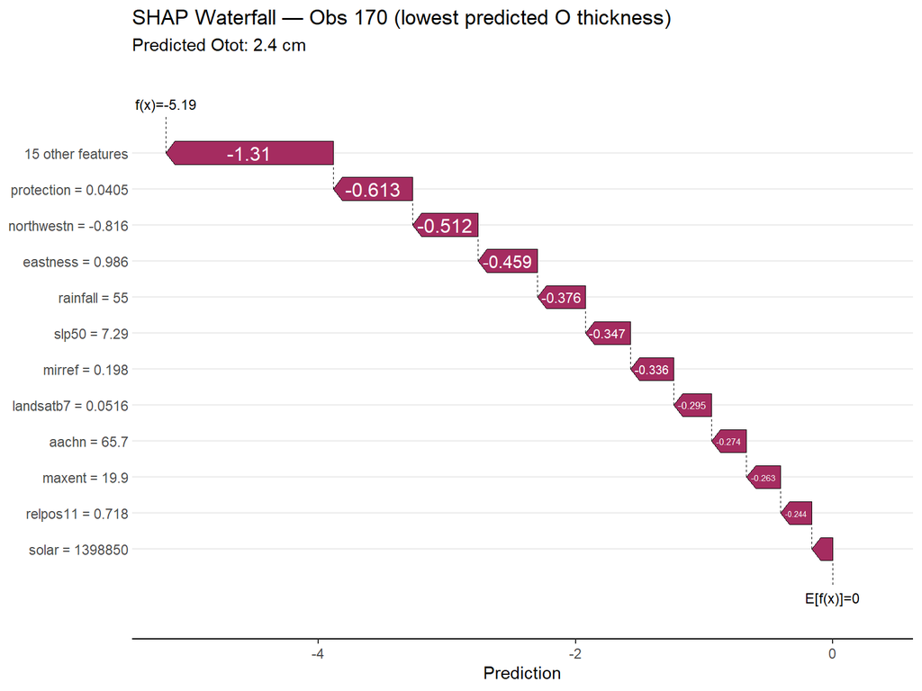

```r
# Waterfall for the thinnest predicted O horizon
sv_waterfall(sv, row_id = worst_obs, max_display = 12) +
  labs(title = paste0("SHAP Waterfall — Obs ", worst_obs,
                      " (lowest predicted O thickness)"),
       subtitle = paste0("Predicted Otot: ",
                         round(rf_shap$predictions[worst_obs], 1),
                         " cm"))
```

> **Questions:** 1. Do the top SHAP features (Mean |SHAP| bar chart) align with your pedological expectations for O horizon development in West Virginia? 2. In the beeswarm plot, identify one feature where blue dots (low values) fall to the right. What does this tell you about the direction of that feature’s effect? 3. Compare the waterfall for the thickest vs. thinnest predicted site. Which features *switch direction* between the two observations, suggesting site-specific interactions? 4. Express the SHAP value for the top feature at the thickest-predicted site as a percentage increase in predicted O thickness (hint: exp(SHAP) − 1).

# 11 Part 10 — Quantile Regression Forest and Uncertainty

## 11.1 Theory: Beyond Point Predictions

A standard RF predicts the **conditional mean** $E[Y | X = x]$. In DSM this is insufficient for operational decision-making — field staff need to know not just the predicted value but **how confident** the model is at each location.

**Quantile Regression Forest (QRF, Meinshausen 2006)** extends RF to predict the full conditional distribution $F(Y | X = x)$ by retaining all training observations in each terminal leaf rather than only the leaf mean. Any quantile can then be read from this empirical distribution:

$$\hat{Q}_\tau(Y | X = x) = \text{weighted
quantile of training responses in leaf}$$

This enables **prediction intervals** without distributional assumptions — no need to assume normality:

- **Median** ($\tau = 0.5$): robust point prediction
- **90% PI**: $[\hat{Q}_{0.05},\ \hat{Q}_{0.95}]$
- **PI width**: a spatial uncertainty map — wide intervals flag sites for targeted field verification

## 11.2 Fit QRF

```r
# ── QRF requires the quantregForest package ────────────────────────────────
# install.packages("quantregForest")
library(quantregForest)

# ── Prepare training and validation matrices ───────────────────────────────
# Convert factors to numeric in both sets
prep_qrf <- function(df, predictors) {
  df[, predictors] <- lapply(df[, predictors], function(v) {
    if (is.numeric(v)) v else as.numeric(as.factor(v))
  })
  as.matrix(df[, predictors])
}

x_train <- prep_qrf(cal_nohist, predictors)
y_train <- cal_nohist$Otot

x_val   <- prep_qrf(val, predictors)
y_val   <- val$Otot

# ── Fit QRF on training data only ─────────────────────────────────────────
set.seed(42)
qrf_model <- quantregForest(
  x        = x_train,
  y        = y_train,
  ntree    = 500,
  mtry     = max(2, floor(length(predictors) / 3)),
  nodesize = 5
)

# ── Predict on held-out validation set ────────────────────────────────────
qrf_pred_cm <- predict(qrf_model, newdata = x_val, what = 0.50)
qrf_lo_cm   <- pmax(predict(qrf_model, newdata = x_val, what = 0.05), 0)
qrf_hi_cm   <- predict(qrf_model, newdata = x_val, what = 0.95)
qrf_width   <- qrf_hi_cm - qrf_lo_cm

# ── Honest PICP on validation set ─────────────────────────────────────────
inside <- y_val >= qrf_lo_cm & y_val <= qrf_hi_cm
picp   <- mean(inside)

cat(sprintf("Validation n:                 %d\n",   length(y_val)))
```

```
#> Validation n:                 73
```

```r
cat(sprintf("Median predicted O thickness: %.2f cm\n", median(qrf_pred_cm)))
```

```
#> Median predicted O thickness: 5.00 cm
```

```r
cat(sprintf("Median 90%% PI width:          %.2f cm\n", median(qrf_width)))
```

```
#> Median 90% PI width:          16.00 cm
```

```r
cat(sprintf("Min / Max PI width:           %.2f / %.2f cm\n", min(qrf_width), max(qrf_width)))
```

```
#> Min / Max PI width:           9.00 / 25.00 cm
```

```r
cat(sprintf("90%% PI coverage (PICP):       %.3f  (target: 0.90)\n", picp))
```

```
#> 90% PI coverage (PICP):       0.918  (target: 0.90)
```

```r
cat(sprintf("Calibration:                  %s\n",
            ifelse(picp > 0.92, "conservative (too wide)",
            ifelse(picp < 0.88, "anti-conservative (too narrow)",
                               "well-calibrated"))))
```

```
#> Calibration:                  well-calibrated
```

## 11.3 Prediction Interval Calibration

**Calibration** checks whether stated 90% PIs actually contain the observation 90% of the time (PICP — Prediction Interval Coverage Probability). Uncalibrated intervals are misleading regardless of model accuracy.

```r
# ── PICP: fraction of observations inside the PI ──────────────────────────
inside <- y_val >= qrf_lo_cm &
          y_val <= qrf_hi_cm

picp <- mean(inside)
cat(sprintf("90%% PI coverage (PICP): %.3f  (target: 0.90)\n", picp))
```

```
#> 90% PI coverage (PICP): 0.918  (target: 0.90)
```

```r
cat(sprintf("Overcoverage (>0.90 = conservative): %s\n",
            ifelse(picp > 0.90, "YES", "NO")))
```

```
#> Overcoverage (>0.90 = conservative): YES
```

## 11.4 Visualise Intervals

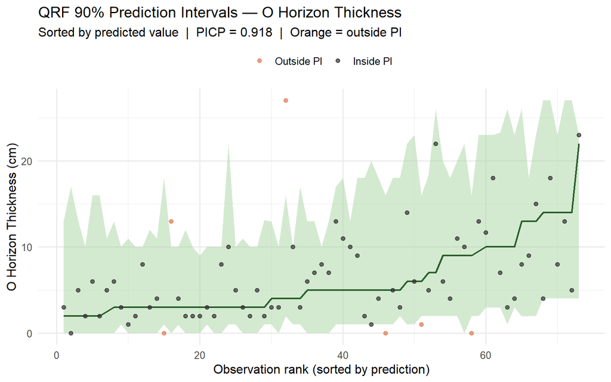

```r
# Sort by predicted value for a clean ribbon plot
plot_df <- data.frame(
  obs    = y_val,          # was soildata_qrf$Otot
  pred   = qrf_pred_cm,
  lo     = qrf_lo_cm,
  hi     = qrf_hi_cm,
  width  = qrf_width,
  inside = inside
) |> dplyr::arrange(pred)

plot_df$rank <- seq_len(nrow(plot_df))

ggplot(plot_df, aes(x = rank)) +
  geom_ribbon(aes(ymin = lo, ymax = hi), fill = "#a8d5a2", alpha = 0.5) +
  geom_line(aes(y = pred), colour = "#2c5f2e", linewidth = 0.8) +
  geom_point(aes(y = obs, colour = inside), size = 1.5, alpha = 0.7) +
  scale_colour_manual(
    values = c("TRUE"  = "#333333",
               "FALSE" = "#e07b54"),
    labels = c("TRUE"  = "Inside PI",
               "FALSE" = "Outside PI"),
    name   = NULL
  ) +
  labs(
    title    = "QRF 90% Prediction Intervals — O Horizon Thickness",
    subtitle = paste0("Sorted by predicted value  |  PICP = ",
                      round(picp, 3), "  |  Orange = outside PI"),
    x        = "Observation rank (sorted by prediction)",
    y        = "O Horizon Thickness (cm)"
  ) +
  theme_minimal(base_size = 12) +
  theme(legend.position = "top")
```

## 11.5 PI Width as Uncertainty Map

PI width is heterogeneous across the landscape — some sites are modelled confidently and others are not. Mapping PI width alongside the point prediction is important for communicating spatial uncertainty.

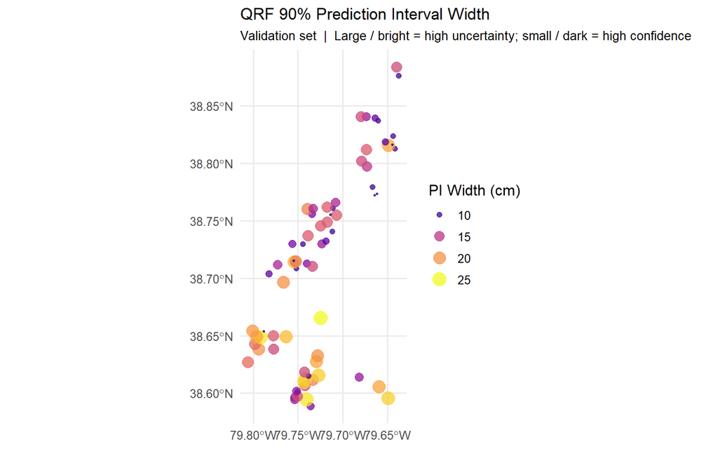

```r
# ── Attach uncertainty to validation spatial data frame ───────────────────
val_sf_qrf <- st_as_sf(
  cbind(
    val,
    qrf_pred_cm = as.numeric(qrf_pred_cm),
    qrf_lo_cm   = as.numeric(qrf_lo_cm),
    qrf_hi_cm   = as.numeric(qrf_hi_cm),
    qrf_width   = as.numeric(qrf_width)
  ),
  coords = c("x", "y"),
  crs    = 4326
)

# ── Static map: PI width as bubble size + color ───────────────────────────
ggplot(val_sf_qrf) +
  geom_sf(aes(colour = qrf_width, size = qrf_width), alpha = 0.75) +
  scale_colour_viridis_c(
    name   = "PI Width (cm)",
    option = "plasma",
    trans  = "sqrt",
    guide  = guide_legend()
  ) +
  scale_size_continuous(
    name   = "PI Width (cm)",      # same name merges the two legends into one
    range  = c(0.5, 5),
    trans  = "sqrt"
  ) +
  labs(
    title    = "QRF 90% Prediction Interval Width",
    subtitle = "Validation set  |  Large / bright = high uncertainty; small / dark = high confidence"
  ) +
  theme_minimal(base_size = 12) +
  theme(
    legend.position  = "right",
    plot.title       = element_text(size = 13),
    plot.subtitle    = element_text(size = 10)
  )
```

Interpretation: PI width typically increases with predicted value for right-skewed soil properties — the model is less certain about thick O horizons (rare observations) than thin ones (abundant observations). This is the correct behavior and reflects training data density, not a model flaw. The spatial map shows uncertainty is not randomly distributed across the landscape — high-uncertainty sites (wide PI, large bright yellow/orange symbols) cluster in the southern portion of the transect around 38.60–38.65°N.

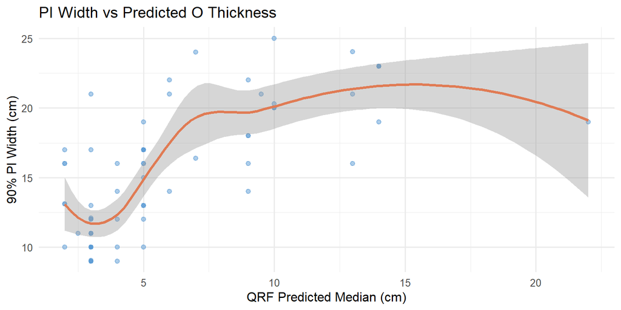

```r
# PI width vs predicted value: does uncertainty scale with magnitude?
ggplot(plot_df, aes(x = pred, y = width)) +
  geom_point(alpha = 0.5, colour = "#5b9bd5", size = 1.8) +
  geom_smooth(method = "loess", colour = "#e07b54", se = TRUE) +
  labs(
    title = "PI Width vs Predicted O Thickness",
    x     = "QRF Predicted Median (cm)",
    y     = "90% PI Width (cm)"
  ) +
  theme_minimal(base_size = 12)
```

**Interpretation:*** PI width shows a U-shaped relationship with predicted O thickness rather than a simple monotonic increase. The model is most confident at moderate predicted values (3–5 cm) where training observations are most dense. Uncertainty is elevated at both extremes — at very low predicted values (0–3 cm) intervals remain wide (~12–15 cm) because near-zero O horizon sites are environmentally ambiguous and difficult to distinguish from thin-but-present O horizons using the available covariates. At high predicted values (>8 cm) PI width rises to ~20 cm and plateaus, reflecting the scarcity of thick O horizon observations in the training data.

## 11.6 QRF vs RF: Point Prediction Comparison

```r
# ── RF mean predictions on validation set ─────────────────────────────────
# rf_shap was trained on soildata_nohist — predict onto val
rf_val_preds <- predict(rf_shap, data = val)$predictions

# ── Build comparison on val set only ──────────────────────────────────────
compare_df <- data.frame(
  observed = y_val,
  rf_mean  = rf_val_preds,
  qrf_med  = as.numeric(qrf_pred_cm)   # already on val set
)

rmse_rf  <- sqrt(mean((compare_df$observed - compare_df$rf_mean)^2))
rmse_qrf <- sqrt(mean((compare_df$observed - compare_df$qrf_med)^2))

cat(sprintf("Val RMSE — RF mean:    %.2f cm\n", rmse_rf))
```

```
#> Val RMSE — RF mean:    2.97 cm
```

```r
cat(sprintf("Val RMSE — QRF median: %.2f cm\n", rmse_qrf))
```

```
#> Val RMSE — QRF median: 5.16 cm
```

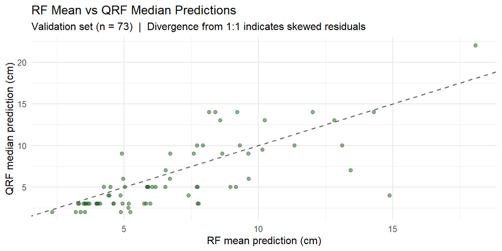

```r
ggplot(compare_df, aes(x = rf_mean, y = qrf_med)) +
  geom_point(alpha = 0.5, colour = "#2c5f2e", size = 1.8) +
  geom_abline(linetype = "dashed", colour = "grey40") +
  labs(
    title    = "RF Mean vs QRF Median Predictions",
    subtitle = "Validation set (n = 73)  |  Divergence from 1:1 indicates skewed residuals",
    x        = "RF mean prediction (cm)",
    y        = "QRF median prediction (cm)"
  ) +
  theme_minimal(base_size = 12)
```

> **Questions:** 1. What is the PICP for your 90% prediction intervals? Are they well-calibrated? 2. Which observations (if any) fall outside the PI? Do they share any characteristics (e.g., soil order, landscape position)? 3. Does PI width increase with predicted O thickness? What does that imply for field verification priorities?

# 12 Part 11 — Spatial CV and Area of Applicability

## 12.1 Theory: Why OOB Error is Not Enough

The OOB (out-of-bag) error in a Random Forest is a free cross-validation estimate — but it assumes training observations are **independent**. Soil pedon data violate this assumption: nearby samples share geology, climate, and parent material, making OOB predictions for a sample informally “assisted” by its geographic neighbours in the training data. The result is **optimistic accuracy**.

**Two distinct problems that are often confused:**

| Problem | Description | Solution |
| --- | --- | --- |
| Spatial CV for model selection | Choosing between models with spatially autocorrelated data | kNNDM or block CV during tuning |
| Map accuracy assessment | Unbiased estimate of accuracy across the full prediction area | Probability-sampled independent validation |

The **kNNDM** (k-fold Nearest Neighbour Distance Matching) framework (Linnenbrink et al. 2023, CAST package) constructs CV folds such that the distribution of distances between validation and training points during CV matches the distribution between prediction locations and training data during mapping. This correctly penalises models that exploit spatial clustering rather than environmental signal.

The **Area of Applicability (AOA, Meyer & Pebesma 2021)** identifies where the model can be trusted: locations where the predictor-space distance to the training data falls within what was encountered during CV. Predictions outside the AOA carry no validated accuracy guarantee.

## 12.2 Setup and Data Preparation

```r
# Install if needed:
# install.packages("CAST")
library(CAST)
library(sf)

# ── Rebuild spatial object with predictors attached ────────────────────────
model_df <- soildata_nohist[, c("x", "y", "Otot", predictors)]

# Remove rows with any NA in predictors
model_df <- model_df[complete.cases(model_df), ]

model_sf <- st_as_sf(model_df, coords = c("x", "y"), crs = 4326)

cat(sprintf("Observations available for spatial CV: %d\n", nrow(model_df)))
```

```
#> Observations available for spatial CV: 249
```

```r
cat(sprintf("Predictors: %d\n", length(predictors)))
```

```
#> Predictors: 26
```

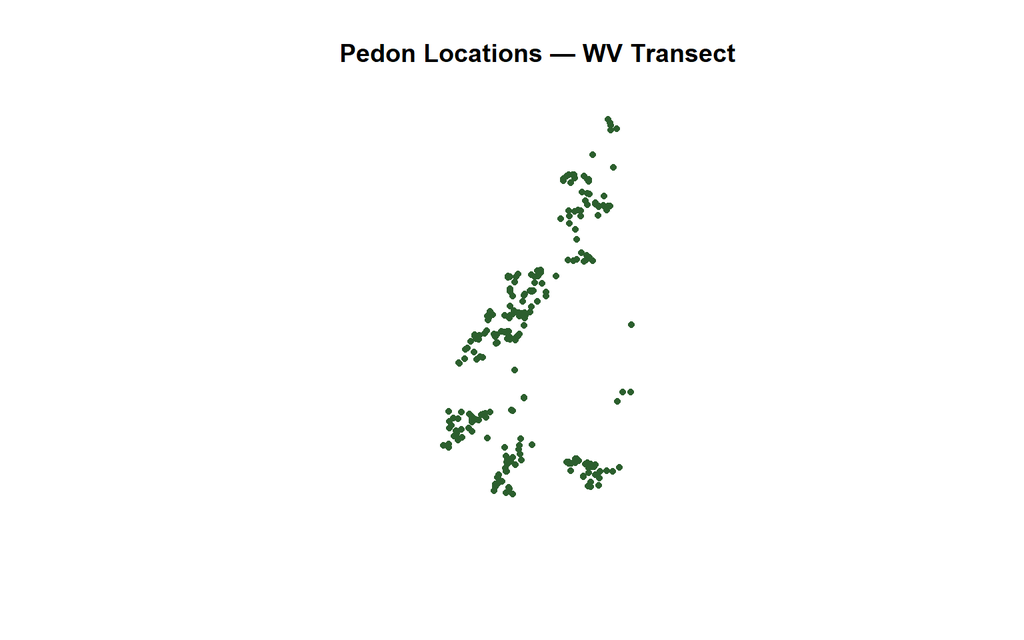

```r
# Quick look at spatial distribution
plot(st_geometry(model_sf), pch = 16, cex = 0.7, col = "#2c5f2e",
     main = "Pedon Locations — WV Transect")
```

## 12.3 kNNDM Cross-Validation

kNNDM matches the fold structure to the actual geographic conditions encountered during prediction. For a field-sample dataset with clustered sampling (legacy pedons), this gives a more realistic error estimate than random 10-fold CV.

```r
# ── Step 1: Create kNNDM folds ─────────────────────────────────────────────
# knndm needs:
#   - tpoints: training point locations (sf object)
#   - modeldomain: the prediction area (sf polygon or point cloud)
# For this exercise we approximate the prediction domain with a convex hull
# buffered slightly — in a real DSM project this would be the MLRA polygon.

study_area <- st_convex_hull(st_union(model_sf)) |>
  st_buffer(dist = 0.05)   # ~5 km buffer in geographic degrees

set.seed(42)
knndm_folds <- knndm(
  tpoints     = model_sf,
  modeldomain = study_area,
  k           = 10,          # 10 folds
  maxp        = 0.5          # max fraction of data in any single fold
)

# Inspect fold structure
cat("kNNDM fold sizes:\n")
```

```
#> kNNDM fold sizes:
```

```r
print(table(knndm_folds$clusters))
```

```
#>
#>  1  2  3  4  5  6  7  8  9 10
#> 34 27 36 33 23 19 24 16 29  8
```

```r
cat(sprintf("kNNDM W-statistic: %.1f\n", knndm_folds$W))
```

```
#> kNNDM W-statistic: 370.6
```

```r
cat(sprintf("Fold sizes range:  %d – %d observations\n",
            min(knndm_folds$indx_test |> sapply(length)),
            max(knndm_folds$indx_test |> sapply(length))))
```

```
#> Fold sizes range:  8 – 36 observations
```

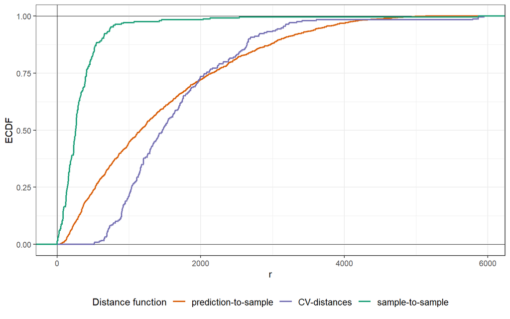

```r
# The sample-to-sample W would be much larger (green vs orange gap)
# kNNDM has reduced it from that baseline to 370.6

# Plot the W-statistic: how well CV distances match prediction distances
plot(knndm_folds, type = "simple",
     main = "kNNDM: Distance Distribution Match")
```

## 12.4 Compare Random CV vs kNNDM CV

```r
# ── Random 10-fold CV ──────────────────────────────────────────────────────
ctrl_random <- trainControl(
  method          = "cv",
  number          = 10,
  savePredictions = "final"
)

# ── kNNDM CV using CAST's CreateSpacetimeFolds ─────────────────────────────
# Pass knndm fold indices directly to caret via indexOut
ctrl_knndm <- trainControl(
  method          = "cv",
  number          = 10,
  index           = knndm_folds$indx_train,
  indexOut        = knndm_folds$indx_test,
  savePredictions = "final"
)

tuning_grid_cv <- expand.grid(
  mtry          = max(2, floor(length(predictors) / 3)),
  splitrule     = "variance",
  min.node.size = 5
)

# ── Train with random CV ────────────────────────────────────────────────────
set.seed(42)
rf_random_cv <- train(
  x         = model_df[, predictors],
  y         = model_df$Otot,
  method    = "ranger",
  trControl = ctrl_random,
  tuneGrid  = tuning_grid_cv,
  num.trees = 500,
  metric    = "RMSE"
)

# ── Train with kNNDM CV ─────────────────────────────────────────────────────
set.seed(42)
rf_knndm_cv <- train(
  x         = model_df[, predictors],
  y         = model_df$Otot,
  method    = "ranger",
  trControl = ctrl_knndm,
  tuneGrid  = tuning_grid_cv,
  num.trees = 500,
  metric    = "RMSE"
)

# ── Extract and compare CV metrics ─────────────────────────────────────────
rmse_random <- min(rf_random_cv$results$RMSE)
rmse_knndm  <- min(rf_knndm_cv$results$RMSE)
r2_random   <- max(rf_random_cv$results$Rsquared)
r2_knndm    <- max(rf_knndm_cv$results$Rsquared)

cv_table <- data.frame(
  Method = c("Random 10-fold CV", "kNNDM 10-fold CV"),
  RMSE_cm  = round(c(rmse_random, rmse_knndm), 4),
  Rsquared = round(c(r2_random,   r2_knndm),   4),
  Notes    = c("Likely optimistic (ignores spatial autocorrelation)",
               "Realistic (matches prediction conditions)")
)
print(cv_table)
```

```
#>              Method RMSE_cm Rsquared
#> 1 Random 10-fold CV  4.8099   0.2773
#> 2  kNNDM 10-fold CV  5.0895   0.1799
#>                                                 Notes
#> 1 Likely optimistic (ignores spatial autocorrelation)
#> 2           Realistic (matches prediction conditions)
```

```r
cat(sprintf("\nAccuracy inflation (random vs kNNDM):\n"))
```

```
#>
#> Accuracy inflation (random vs kNNDM):
```

```r
cat(sprintf("  RMSE increase: %.4f cm  (%.1f%% relative)\n",
            rmse_knndm - rmse_random,
            (rmse_knndm / rmse_random - 1) * 100))
```

```
#>   RMSE increase: 0.2796 cm  (5.8% relative)
```

```r
cat(sprintf("  R\u00b2 decrease:  %.4f\n", r2_random - r2_knndm))
```

```
#>   R² decrease:  0.0974
```

> **Interpretation:** The gap between random CV (RMSE = 4.81 cm, R² = 0.277) and kNNDM CV (RMSE = 5.09 cm, R² = 0.180) is the key result. Random CV overstates R² by 0.097 — a 54% relative inflation — and understates RMSE by 0.28 cm. This is the spatial autocorrelation penalty: random CV assigns nearby clustered pedons to validation folds, allowing the model to exploit spatial proximity rather than genuine environmental signal, producing optimistically inflated accuracy. kNNDM forces evaluation across distances that better represent true prediction conditions, revealing the honest map accuracy.

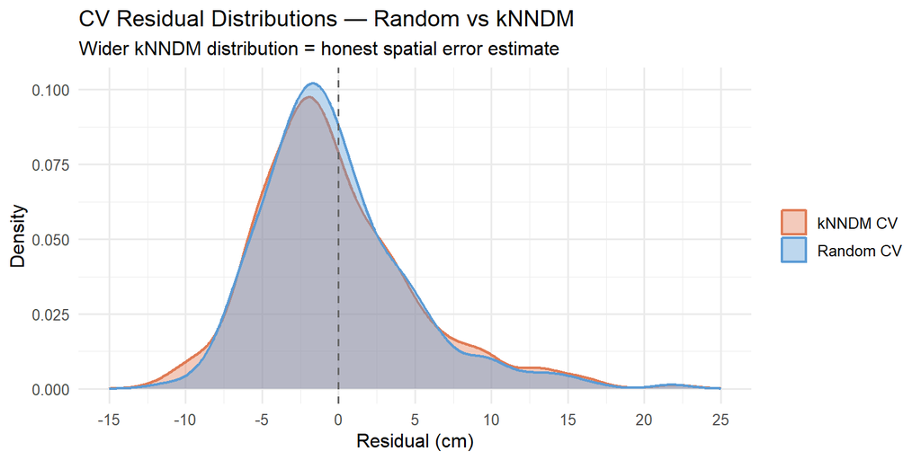

```r
# ── Residuals: random CV vs kNNDM CV ──────────────────────────────────────
pred_random <- rf_random_cv$pred[order(rf_random_cv$pred$rowIndex), ]
pred_knndm  <- rf_knndm_cv$pred[order(rf_knndm_cv$pred$rowIndex), ]

# Match to observed
obs_vals <- model_df$Otot[
  as.integer(rownames(model_df)) %in% pred_random$rowIndex
]

resid_random <- pred_random$obs - pred_random$pred
resid_knndm  <- pred_knndm$obs  - pred_knndm$pred

resid_df <- data.frame(
  residual = c(resid_random, resid_knndm),
  method   = rep(c("Random CV", "kNNDM CV"), c(length(resid_random),
                                                length(resid_knndm)))
)

ggplot(resid_df, aes(x = residual, fill = method, colour = method)) +
  geom_density(alpha = 0.4, linewidth = 0.8) +
  scale_fill_manual(values  = c("kNNDM CV" = "#E07B54", "Random CV" = "#5B9BD5")) +
  scale_colour_manual(values = c("kNNDM CV" = "#E07B54", "Random CV" = "#5B9BD5")) +
  geom_vline(xintercept = 0, colour = "grey40", linetype = "dashed") +
  scale_x_continuous(
    limits = c(-15, 25),          # expand to show full tails
    breaks = seq(-15, 25, by = 5)
  ) +
  labs(
    title    = "CV Residual Distributions — Random vs kNNDM",
    subtitle = "Wider kNNDM distribution = honest spatial error estimate",
    x        = "Residual (cm)",
    y        = "Density",
    fill     = NULL,
    colour   = NULL
  ) +
  theme_minimal(base_size = 12) +
  theme(legend.position = "right")
```

## 12.5 Area of Applicability

The AOA delineates where the model’s reported CV accuracy is expected to hold. Locations with predictor combinations far from the training data (high dissimilarity index) fall outside the AOA — predictions there should not be reported with the same confidence as predictions within the AOA.

```r
# ── Rebuild spatial object from cal_nohist only ───────────────────────────
cal_sf <- st_as_sf(cal_nohist, coords = c("x", "y"), crs = 4326)

study_area <- st_convex_hull(st_union(cal_sf)) |>
  st_buffer(dist = 0.05)

# ── New kNNDM folds based on cal_nohist ───────────────────────────────────
set.seed(42)
knndm_cal <- knndm(
  tpoints     = cal_sf,
  modeldomain = study_area,
  k           = 10
)

# ── New trainControl using cal_nohist fold indices ────────────────────────
ctrl_knndm_cal <- trainControl(
  method          = "cv",
  index           = knndm_cal$indx_train,
  indexOut        = knndm_cal$indx_test,
  savePredictions = "final",
  returnResamp    = "all"
)

# ── Retrain AOA model ─────────────────────────────────────────────────────
set.seed(42)
rf_aoa_model <- train(
  x          = cal_nohist[, predictors[-2]],
  y          = cal_nohist$Otot,
  method     = "ranger",
  trControl  = ctrl_knndm_cal,
  tuneGrid   = tuning_grid_cv,
  num.trees  = 500,
  metric     = "RMSE",
  importance = "permutation"
)

# ── Compute trainDI from calibration model ────────────────────────────────
train_di <- trainDI(rf_aoa_model)
```

[output not shown]

```r
# ── Evaluate AOA on held-out validation set ───────────────────────────────
aoa_result <- aoa(
  newdata  = val[, predictors[-2]],   # truly held-out
  model    = rf_aoa_model,
  trainDI  = train_di
)

di_vals  <- aoa_result$DI
aoa_mask <- aoa_result$AOA

cat(sprintf("Validation points inside AOA:  %d (%.1f%%)\n",
            sum(aoa_mask == 1), mean(aoa_mask == 1) * 100))
```

```
#> Validation points inside AOA:  72 (98.6%)
```

```r
cat(sprintf("Validation points outside AOA: %d (%.1f%%)\n",
            sum(aoa_mask == 0), mean(aoa_mask == 0) * 100))
```

```
#> Validation points outside AOA: 1 (1.4%)
```

```r
cat(sprintf("DI range: %.4f – %.4f  (threshold: %.4f)\n",
            min(di_vals), max(di_vals), train_di$threshold))
```

```
#> DI range: 0.0000 – 0.7757  (threshold: 0.4718)
```

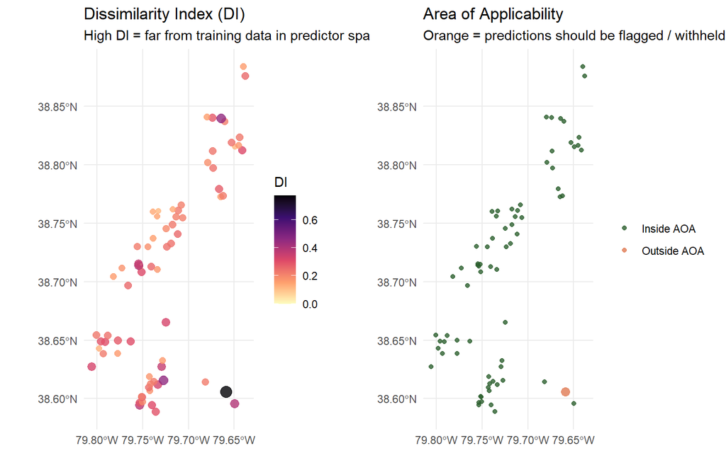

```r
# ── Build validation spatial object ───────────────────────────────────────
val_sf <- st_as_sf(val, coords = c("x", "y"), crs = 4326)

# ── Attach DI and AOA to validation spatial object ────────────────────────
val_sf$DI  <- as.numeric(di_vals)
val_sf$AOA <- factor(aoa_mask, levels = c(1, 0),
                     labels = c("Inside AOA", "Outside AOA"))

# ── Map 1: Dissimilarity Index ─────────────────────────────────────────────
p_di <- ggplot(val_sf) +
  geom_sf(aes(colour = DI, size = DI), alpha = 0.8) +
  scale_colour_viridis_c(name = "DI", option = "magma", direction = -1) +
  scale_size_continuous(name = "DI", range = c(0.5, 4)) +
  labs(title    = "Dissimilarity Index (DI)",
       subtitle = "High DI = far from training data in predictor space") +
  theme_minimal(base_size = 11) +
  guides(size = "none")

# ── Map 2: AOA binary mask ─────────────────────────────────────────────────
p_aoa <- ggplot(val_sf) +
  geom_sf(aes(colour = AOA, size = AOA), alpha = 0.8) +
  scale_colour_manual(
    values = c("Inside AOA"  = "#2c5f2e",
               "Outside AOA" = "#e07b54"),
    name   = NULL
  ) +
  scale_size_manual(
    values = c("Inside AOA"  = 1.5,
               "Outside AOA" = 3.0),
    guide  = "none"
  ) +
  labs(title    = "Area of Applicability",
       subtitle = "Orange = predictions should be flagged / withheld") +
  theme_minimal(base_size = 11)

gridExtra::grid.arrange(p_di, p_aoa, ncol = 2)
```

## 12.6 DI vs Prediction Error

The DI should correlate with actual prediction error — higher DI means less reliable predictions. This relationship validates the AOA concept on your dataset.

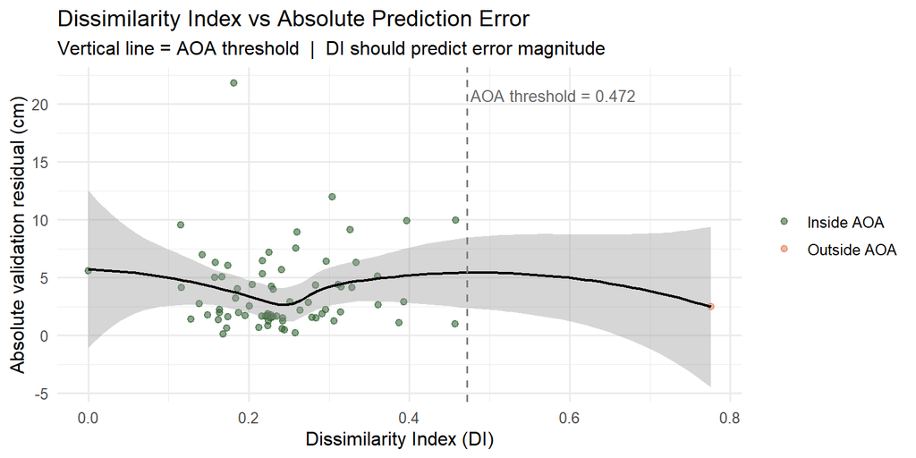

```r
# ── Validation predictions from rf_aoa_model ──────────────────────────────
val_preds     <- predict(rf_aoa_model, newdata = val[, predictors[-2]])
val_resid_abs <- abs(val$Otot - val_preds)

# ── DI vs prediction error on validation set ──────────────────────────────
di_error_df <- data.frame(
  DI        = as.numeric(di_vals),
  abs_resid = val_resid_abs,
  AOA       = factor(aoa_mask, levels = c(1, 0),
                     labels = c("Inside AOA", "Outside AOA"))
)

# ── AOA threshold ─────────────────────────────────────────────────────────
aoa_threshold <- train_di$threshold

ggplot(di_error_df, aes(x = DI, y = abs_resid, colour = AOA)) +
  geom_point(alpha = 0.55, size = 1.8) +
  geom_smooth(method = "loess", se = TRUE, colour = "black",
              linewidth = 0.8) +
  geom_vline(xintercept = aoa_threshold,
             linetype = "dashed", colour = "grey50") +
  annotate("text",
           x     = aoa_threshold + 0.005,
           y     = max(val_resid_abs) * 0.95,
           label = paste0("AOA threshold = ", round(aoa_threshold, 3)),
           hjust = 0, size = 3.5, colour = "grey40") +
  scale_colour_manual(
    values = c("Inside AOA"  = "#2c5f2e",
               "Outside AOA" = "#e07b54"),
    name   = NULL
  ) +
  labs(
    title    = "Dissimilarity Index vs Absolute Prediction Error",
    subtitle = "Vertical line = AOA threshold  |  DI should predict error magnitude",
    x        = "Dissimilarity Index (DI)",
    y        = "Absolute validation residual (cm)"
  ) +
  theme_minimal(base_size = 12)
```

## 12.7 Reporting Summary

```r
# ── Complete validation summary table ──────────────────────────────────────
# kNNDM CV predictions are already in cm (model trained on raw Otot)
val_rmse_cv <- sqrt(mean((pred_knndm$obs - pred_knndm$pred)^2))
val_r2_cv   <- 1 - sum((pred_knndm$obs - pred_knndm$pred)^2) /
                   sum((pred_knndm$obs - mean(pred_knndm$obs))^2)

reporting <- data.frame(
  Metric  = c(
    "OOB RMSE (cm)",
    "OOB R\u00b2",
    "Random CV RMSE (cm)",
    "Random CV R\u00b2",
    "kNNDM CV RMSE (cm)",
    "kNNDM CV R\u00b2",
    "QRF 90% PICP",
    "Median 90% PI width (cm)",
    "Pct observations inside AOA"
  ),
  Value   = c(
    round(sqrt(rf_shap$prediction.error), 3),
    round(rf_shap$r.squared, 4),
    round(rmse_random, 3),
    round(r2_random,   4),
    round(rmse_knndm,  3),
    round(r2_knndm,    4),
    round(picp, 3),
    round(median(qrf_width), 2),
    paste0(round(mean(aoa_mask == 1) * 100, 1), "%")
  )
)
print(reporting, row.names = FALSE)
```

```
#>                       Metric  Value
#>                OOB RMSE (cm)  4.842
#>                       OOB R² 0.2559
#>          Random CV RMSE (cm)   4.81
#>                 Random CV R² 0.2773
#>           kNNDM CV RMSE (cm)   5.09
#>                  kNNDM CV R² 0.1799
#>                 QRF 90% PICP  0.918
#>     Median 90% PI width (cm)     16
#>  Pct observations inside AOA  98.6%
```

> **Reporting guidance:** Report the **kNNDM CV RMSE and R²** (not OOB, not random CV). Include the AOA percentage to communicate the spatial extent of validated predictions. If PICP < 0.85 or > 0.95, note whether prediction intervals are anti-conservative or conservative respectively.

> **Questions:** 1. By how much (in % RMSE) did kNNDM CV inflate the error estimate vs random CV? Does this match the 20–60% range reported in the DSM literature? 2. What percentage of observations fall outside the AOA? What do those locations have in common (examine their predictor values)? 3. Does the DI correlate with prediction error as expected? Where does the relationship break down? 4. If you were writing the validation section of an MLRA correlation document for O horizon thickness in this MLRA, which metrics from the reporting table would you cite, and why?

# 13 Part 12 — RF Classification with Grid Search (Land Cover)

## 13.1 Load Land Cover Training Data

```r
# Download land cover classification training data
url_lc <- "https://raw.githubusercontent.com/ncss-tech/stats_for_soil_survey/master/archive/chapters/8_Tree_models/IAD16_train.csv"
download.file(url_lc, "LCdata.csv", mode = "wb")

LCtrain <- read.csv("LCdata.csv", header = TRUE)
train   <- LCtrain[, c(3:7, 10)]
train$Observed <- as.factor(train$Observed)

cat("Training samples:", nrow(train), "\n")
```

```
#> Training samples: 2137
```

```r
table(train$Observed)
```

```
#>
#>    Barren      Crop    Forest Grassland     Shrub     Urban     Water
#>        65        40       921       571        28       465        47
```

## 13.2 Build Initial Random Forest

```r
set.seed(42)
rf_initial <- randomForest(
  as.factor(Observed) ~ .,
  data      = train,
  ntree     = 500,
  mtry      = 2,
  importance = TRUE,
  proximity  = TRUE,
  keep.forest = TRUE
)

print(rf_initial)
```

```
#>
#> Call:
#>  randomForest(formula = as.factor(Observed) ~ ., data = train,      ntree = 500, mtry = 2, importance = TRUE, proximity = TRUE,      keep.forest = TRUE)
#>                Type of random forest: classification
#>                      Number of trees: 500
#> No. of variables tried at each split: 2
#>
#>         OOB estimate of  error rate: 14.23%
#> Confusion matrix:
#>           Barren Crop Forest Grassland Shrub Urban Water class.error
#> Barren        29    0      0         6     0    30     0  0.55384615
#> Crop           1    3      3        31     0     2     0  0.92500000
#> Forest         0    0    854        66     0     0     1  0.07274701
#> Grassland      3    3     86       474     1     4     0  0.16987741
#> Shrub          0    0     15        13     0     0     0  1.00000000
#> Urban          4    0      1         7     0   444     9  0.04516129
#> Water          1    0      3         0     0    14    29  0.38297872
```

```r
# ── A priori class proportions from training data ──────────────────────────
q <- prop.table(table(train$Observed))
cat("A priori class proportions (q):\n")
```

```
#> A priori class proportions (q):
```

```r
print(round(q, 4))
```

```
#>
#>    Barren      Crop    Forest Grassland     Shrub     Urban     Water
#>    0.0304    0.0187    0.4310    0.2672    0.0131    0.2176    0.0220
```

```r
# ── Confusion matrix from OOB predictions ─────────────────────────────────
# randomForest stores OOB predicted classes directly
obs_oob  <- train$Observed
pred_oob <- rf_initial$predicted   # OOB predictions — one per training observation

cm <- table(Observed = obs_oob, Predicted = pred_oob)
cat("\nConfusion Matrix (OOB):\n")
```

```
#>
#> Confusion Matrix (OOB):
```

```r
print(cm)
```

```
#>            Predicted
#> Observed    Barren Crop Forest Grassland Shrub Urban Water
#>   Barren        29    0      0         6     0    30     0
#>   Crop           1    3      3        31     0     2     0
#>   Forest         0    0    854        66     0     0     1
#>   Grassland      3    3     86       474     1     4     0
#>   Shrub          0    0     15        13     0     0     0
#>   Urban          4    0      1         7     0   444     9
#>   Water          1    0      3         0     0    14    29
```

```r
# ── Overall accuracy ───────────────────────────────────────────────────────
Po <- mean(obs_oob == pred_oob)
n  <- sum(cm)

cat(sprintf("Total observations: %d\n", n))
```

```
#> Total observations: 2137
```

```r
cat(sprintf("Overall accuracy (Po): %.4f\n", Po))
```

```
#> Overall accuracy (Po): 0.8577
```

```r
# ── Kappa ───────────────────────────────────────────────────────
row_sums <- rowSums(cm)
col_sums <- colSums(cm)
Pe_kappa <- sum(row_sums * col_sums) / n^2
kappa    <- (Po - Pe_kappa) / (1 - Pe_kappa)

cat(sprintf("Pe (Kappa): %.4f\n", Pe_kappa))
```

```
#> Pe (Kappa): 0.3200
```

```r
cat(sprintf("Kappa:      %.4f\n", kappa))
```

```
#> Kappa:      0.7908
```

```r
# ── Expected accuracy (chance) ─────────────────────────────────────────────
Pe <- sum(q^2)
cat(sprintf("Expected accuracy (Pe): %.4f\n", Pe))
```

```
#> Expected accuracy (Pe): 0.3064
```

```r
# ── Tau ────────────────────────────────────────────────────────────────────
tau <- (Po - Pe) / (1 - Pe)
cat(sprintf("Tau:                    %.4f\n", tau))
```

```
#> Tau:                    0.7949
```

```r
# ── Per-class tau ──────────────────────────────────────────────────────────
prod_acc <- diag(cm) / rowSums(cm)   # producer's accuracy per class
tau_k    <- (prod_acc - q) / (1 - q)

tau_table <- data.frame(
  Class         = names(prod_acc),
  N             = rowSums(cm),
  q_k           = round(as.numeric(q), 4),
  Prod_Acc      = round(prod_acc, 4),
  Tau_k         = round(as.numeric(tau_k), 4)
)
cat("\nPer-class tau:\n")
```

```
#>
#> Per-class tau:
```

```r
print(tau_table, row.names = FALSE)
```

```
#>      Class   N    q_k Prod_Acc   Tau_k
#>     Barren  65 0.0304   0.4462  0.4288
#>       Crop  40 0.0187   0.0750  0.0574
#>     Forest 921 0.4310   0.9273  0.8722
#>  Grassland 571 0.2672   0.8301  0.7682
#>      Shrub  28 0.0131   0.0000 -0.0133
#>      Urban 465 0.2176   0.9548  0.9423
#>      Water  47 0.0220   0.6170  0.6084
```

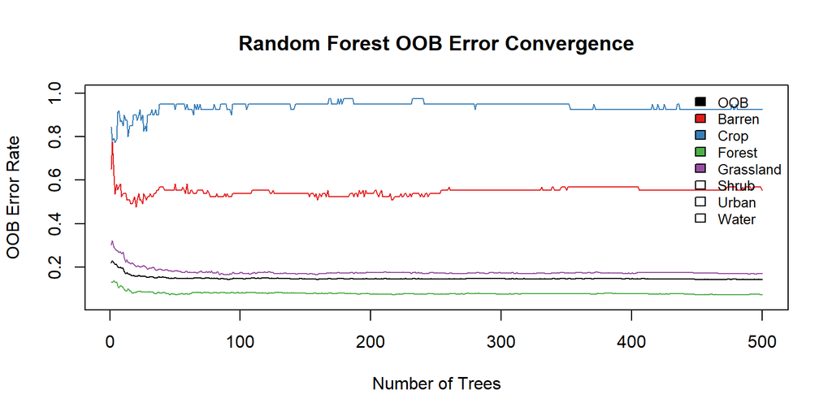

```r
# OOB error by number of trees
err <- rf_initial$err.rate

# Plot convergence
matplot(err, type = "l", lty = 1,
        col  = c("black", "#e41a1c", "#377eb8", "#4daf4a", "#984ea3")[1:ncol(err)],
        xlab = "Number of Trees", ylab = "OOB Error Rate",
        main = "Random Forest OOB Error Convergence")
legend("topright", legend = colnames(err),
       fill = c("black", "#e41a1c", "#377eb8", "#4daf4a", "#984ea3")[1:ncol(err)],
       bty = "n", cex = 0.8)
```

```r
# Final OOB error
cat(sprintf("Final OOB error rate: %.4f (%.1f%%)\n",
            err[nrow(err), "OOB"], err[nrow(err), "OOB"] * 100))
```

```
#> Final OOB error rate: 0.1423 (14.2%)
```

```r
# True landscape: 80% forest, 20% urban
# Two different validation sampling designs, same model performance

# ── Scenario A: proportional sample (reflects landscape) ──────────────────
cm_A <- matrix(c(76, 4,    # forest: 76 correct, 4 wrong
                  3, 17),  # urban:  17 correct, 3 wrong
               nrow = 2, byrow = TRUE,
               dimnames = list(c("forest","urban"), c("forest","urban")))

n_A      <- sum(cm_A)
Po_A     <- sum(diag(cm_A)) / n_A
Pe_A     <- sum(rowSums(cm_A) * colSums(cm_A)) / n_A^2
kappa_A  <- (Po_A - Pe_A) / (1 - Pe_A)

# ── Scenario B: equal stratified sample (50 per class) ────────────────────
cm_B <- matrix(c(47, 3,    # forest: 47 correct, 3 wrong
                  4, 46),  # urban:  46 correct, 4 wrong
               nrow = 2, byrow = TRUE,
               dimnames = list(c("forest","urban"), c("forest","urban")))

n_B      <- sum(cm_B)
Po_B     <- sum(diag(cm_B)) / n_B
Pe_B     <- sum(rowSums(cm_B) * colSums(cm_B)) / n_B^2
kappa_B  <- (Po_B - Pe_B) / (1 - Pe_B)

# ── Tau: same landscape proportions for both ──────────────────────────────
q       <- c(forest = 0.80, urban = 0.20)
Pe_tau  <- sum(q^2)
tau_A   <- (Po_A - Pe_tau) / (1 - Pe_tau)
tau_B   <- (Po_B - Pe_tau) / (1 - Pe_tau)

cat(sprintf("Scenario A — Po: %.3f  Kappa: %.3f  Tau: %.3f\n",
            Po_A, kappa_A, tau_A))
```

```
#> Scenario A — Po: 0.930  Kappa: 0.785  Tau: 0.781
```

```r
cat(sprintf("Scenario B — Po: %.3f  Kappa: %.3f  Tau: %.3f\n",
            Po_B, kappa_B, tau_B))
```

```
#> Scenario B — Po: 0.930  Kappa: 0.860  Tau: 0.781
```

> Kappa estimates chance agreement from the validation sample marginals, so its value changes when the same model is evaluated with different sampling designs (proportional vs. equal stratified). Tau fixes the chance-agreement baseline using known landscape proportions, making it invariant to sampling design and therefore more appropriate for reporting map accuracy across the true class distribution.

## 13.3 Variable Importance

Variable importance in RF is computed as **permutation importance (MDA)**: for each feature, the OOB samples are shuffled and prediction error is re-measured. The drop in accuracy — averaged across all trees — is the importance score. This is unbiased with respect to feature cardinality and more reliable than single-tree importance.

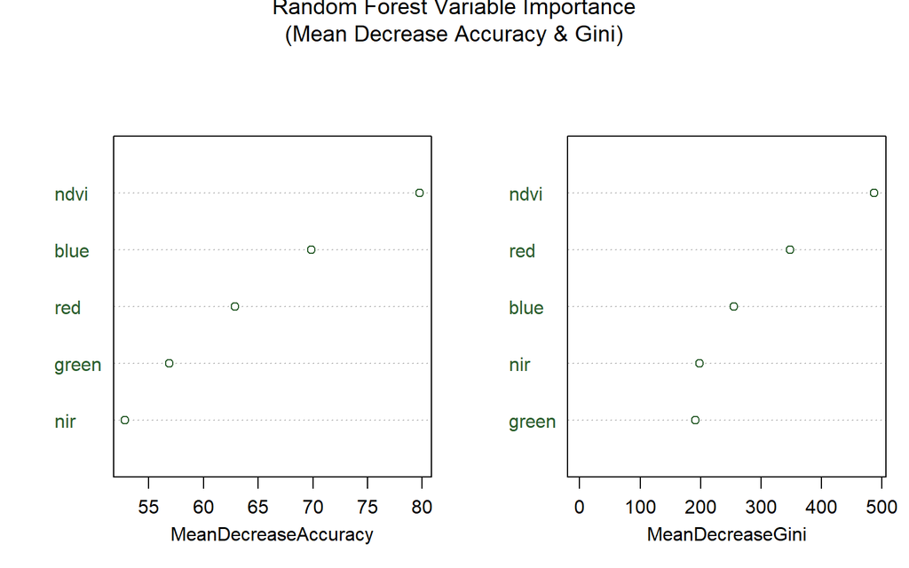

```r
varImpPlot(rf_initial,
           main = "Random Forest Variable Importance\n(Mean Decrease Accuracy & Gini)",
           col  = "#2c5f2e")
```

> **Questions:**  
> 1. What is the OOB error rate?  
> 2. Which predictor has the greatest drop in accuracy when permuted?  
> 3. Do the two importance measures (MDA and Gini) agree on the top predictors?

## 13.4 Hyperparameter Grid Search

```r
# Define search grid
mtry_grid     <- seq(2, 4, 1)
nodesize_grid <- seq(1, 8, 2)
ntree_grid    <- seq(200, 800, 100)

hyper_grid <- expand.grid(
  mtry     = mtry_grid,
  nodesize = nodesize_grid,
  ntree    = ntree_grid
)

cat(sprintf("Testing %d hyperparameter combinations...\n", nrow(hyper_grid)))
```

```
#> Testing 84 hyperparameter combinations...
```

```r
oob_err <- numeric(nrow(hyper_grid))

for (i in seq_len(nrow(hyper_grid))) {
  model      <- randomForest(
    formula  = Observed ~ .,
    data     = train,
    mtry     = hyper_grid$mtry[i],
    nodesize = hyper_grid$nodesize[i],
    ntree    = hyper_grid$ntree[i]
  )
  oob_err[i] <- model$err.rate[nrow(model$err.rate), "OOB"]
}

opt_i <- which.min(oob_err)
cat("\nOptimal hyperparameters:\n")
```

```
#>
#> Optimal hyperparameters:
```

```r
print(hyper_grid[opt_i, ])
```

```
#>    mtry nodesize ntree
#> 44    3        5   500
```

```r
cat(sprintf("Optimal OOB error: %.4f\n", oob_err[opt_i]))
```

```
#> Optimal OOB error: 0.1357
```

```r
# Build optimized RF
rf_opt <- randomForest(
  Observed ~ .,
  data        = train,
  ntree       = hyper_grid$ntree[opt_i],
  mtry        = hyper_grid$mtry[opt_i],
  nodesize    = hyper_grid$nodesize[opt_i],
  importance  = TRUE,
  keep.forest = TRUE
)

cat("Initial RF OOB error:  ", rf_initial$err.rate[nrow(rf_initial$err.rate), "OOB"], "\n")
```

```
#> Initial RF OOB error:   0.1422555
```

```r
cat("Optimized RF OOB error:", rf_opt$err.rate[nrow(rf_opt$err.rate), "OOB"], "\n")
```

```
#> Optimized RF OOB error: 0.1431914
```

# 14 Part 13 — Predict and Map Land Cover

## 14.1 Load Imagery

```r
library(terra)

# Download sample NAIP imagery (5-band + NDVI)
url_img <- "https://raw.githubusercontent.com/ncss-tech/stats_for_soil_survey/master/archive/chapters/8_Tree_models/NAIP_5m.zip"
download.file(url_img, "NAIP_5m.zip", mode = "wb")
unzip("NAIP_5m.zip")

# Read the 4-band NAIP image (red, green, blue, NIR)
x1 <- rast("m_3807706_nw_5m.tif")
names(x1)
```

[output not shown]

## 14.2 Compute NDVI and Predict

```r
# NDVI function
calc_ndvi <- function(img, red_band = 1, nir_band = 4) {
  (img[[nir_band]] - img[[red_band]]) / (img[[nir_band]] + img[[red_band]])
}

ndvi_layer <- calc_ndvi(x1)
plot(ndvi_layer, main = "NDVI")

# Stack with computed NDVI
x <- c(x1, ndvi_layer)
names(x) <- c("red", "green", "blue", "nir", "ndvi")

# Predict land cover using optimized RF model
LC_class <- predict(x, rf_opt, type = "response")

# Distinct qualitative colors — one per class
lc_classes <- levels(train$Observed)
n_classes  <- length(lc_classes)

# RColorBrewer "Set1" / "Dark2" palette gives maximally distinct hues
lc_colors <- c("#e41a1c", "#377eb8", "#4daf4a", "#984ea3",
               "#ff7f00", "#a65628", "#f781bf", "#999999")[seq_len(n_classes)]

plot(LC_class,
     col   = lc_colors,
     main  = "Predicted Land Cover",
     plg   = list(title = "Land Cover Class", cex = 0.85))

writeRaster(LC_class, "LC_Class_map.tif", overwrite = TRUE)

# Probability surface — one layer per class, labeled with class name
LC_prob <- predict(x, rf_opt, type = "prob")
names(LC_prob) <- lc_classes   # label each layer with its class name

# Plot each class probability map individually
# 3-stop diverging palette: blue (low) → yellow (mid ~0.5) → red (high)
# This maximises perceptual contrast at mid-range probabilities
prob_pal <- colorRampPalette(c("#2166ac", "#ffffbf", "#d73027"))(100)

par(mfrow = c(ceiling(n_classes / 3), 3),
    mar    = c(2, 2, 3, 4))
for (cls in lc_classes) {
  plot(LC_prob[[cls]],
       main   = paste("P(", cls, ")", sep = ""),
       col    = prob_pal,
       range  = c(0, 1))   # fix scale so maps are directly comparable
}
par(mfrow = c(1, 1))
```

[output not shown]

```r
# ── Shannon Entropy and uncertainty metrics from probability surface ───────
library(terra)

# ── 1. Shannon Entropy ─────────────────────────────────────────────────────
# H = -sum(p * log(p)) across all classes at each pixel
# Maximum entropy = log(n_classes) — normalise to 0-1 for comparability
entropy_raw <- app(LC_prob, fun = function(p) {
  p   <- p[p > 0]           # exclude zero probabilities (log(0) undefined)
  -sum(p * log(p))
})

entropy_norm <- entropy_raw / log(n_classes)   # 0 = certain, 1 = maximum uncertainty
names(entropy_raw)  <- "Shannon_Entropy"
names(entropy_norm) <- "Shannon_Entropy_Normalised"

# ── 2. Confusion Index ─────────────────────────────────────────────────────
# CI = 1 - (p1 - p2) where p1 = highest class probability, p2 = second highest
# CI near 1 = two classes nearly equally likely (confused)
# CI near 0 = one class dominates (confident)
confusion_index <- app(LC_prob, fun = function(p) {
  p_sorted <- sort(p, decreasing = TRUE)
  1 - (p_sorted[1] - p_sorted[2])
})
names(confusion_index) <- "Confusion_Index"

# ── 3. Maximum Probability (confidence of winning class) ──────────────────
max_prob <- app(LC_prob, max)
names(max_prob) <- "Max_Probability"

# ── 4. Margin (difference between top two class probabilities) ─────────────
margin <- app(LC_prob, fun = function(p) {
  p_sorted <- sort(p, decreasing = TRUE)
  p_sorted[1] - p_sorted[2]
})
names(margin) <- "Margin"

# ── 5. Combine all uncertainty layers ─────────────────────────────────────
uncertainty_stack <- c(entropy_norm, confusion_index, max_prob, margin)

# ── 6. Plot all uncertainty metrics ───────────────────────────────────────
unc_pal     <- colorRampPalette(c("#2166ac", "#ffffbf", "#d73027"))(100)
conf_pal    <- colorRampPalette(c("#1a9641", "#ffffbf", "#d7191c"))(100)
maxprob_pal <- colorRampPalette(c("#d73027", "#ffffbf", "#1a9641"))(100)

par(mfrow = c(2, 2), mar = c(2, 2, 3, 4))

plot(entropy_norm,
     main  = "Shannon Entropy (normalised)",
     col   = unc_pal,
     range = c(0, 1))

plot(confusion_index,
     main  = "Confusion Index",
     col   = conf_pal,
     range = c(0, 1))

plot(max_prob,
     main  = "Max Class Probability",
     col   = maxprob_pal,
     range = c(0, 1))

plot(margin,
     main  = "Margin (p1 - p2)",
     col   = maxprob_pal,
     range = c(0, 1))

par(mfrow = c(1, 1))

# ── 7. Write uncertainty rasters to disk ──────────────────────────────────
writeRaster(entropy_norm,    "entropy_normalised.tif",  overwrite = TRUE)
writeRaster(confusion_index, "confusion_index.tif",     overwrite = TRUE)
writeRaster(max_prob,        "max_probability.tif",     overwrite = TRUE)
writeRaster(margin,          "margin.tif",              overwrite = TRUE)

# ── 8. Summary statistics across the mapped area ──────────────────────────
cat("=== Uncertainty Summary ===\n")
cat(sprintf("Mean Shannon Entropy (0-1):  %.3f\n", global(entropy_norm,    "mean", na.rm=TRUE)[[1]]))
cat(sprintf("Mean Confusion Index:        %.3f\n", global(confusion_index, "mean", na.rm=TRUE)[[1]]))
cat(sprintf("Mean Max Probability:        %.3f\n", global(max_prob,        "mean", na.rm=TRUE)[[1]]))
cat(sprintf("Mean Margin (p1-p2):         %.3f\n", global(margin,          "mean", na.rm=TRUE)[[1]]))

# Fraction of pixels with high confusion (CI > 0.8)
ci_vals <- values(confusion_index, na.rm = TRUE)
cat(sprintf("Pixels with CI > 0.8:        %.1f%%\n", mean(ci_vals > 0.8) * 100))
```

[output not shown]

**Shannon Entropy** captures overall spread across all classes — useful when more than two classes are competing. **Confusion Index** focuses specifically on the competition between the top two classes — a pixel can have moderate entropy but low confusion if one class clearly dominates. **Max Probability** is the simplest and most interpretable — areas below 0.5 should be flagged for verification. **Margin** is the most sensitive to boundary uncertainty and aligns closely with what a field scientist would call a transition zone between map units.

> **Question:** Examine the probability surface for each class. Which areas of the landscape show the highest prediction uncertainty (probability near 0.5)? What landscape features might explain this?

# 15 Summary: Key Takeaways

| Concept | What to Remember |
| --- | --- |
| **Decision Tree** | Recursive binary partitioning; interpretable but high variance |
| **Pruning (1-SE rule)** | Selects simplest tree within 1 SE of minimum CV error |
| **Multi-class vs Binary** | Binary response typically outperforms multi-class for spodic; collapsing classes removes ambiguous boundaries |
| **Gini vs Entropy** | Produce nearly identical trees; Gini is faster |
| **Histosol outlier** | Single extreme observation can substantially inflate MSE; always inspect distribution before modeling |
| **Bagging** | Averaging trees reduces variance without changing bias |
| **Random Feature Subsampling** | Decorrelates trees; key RF innovation |
| **OOB Error** | Free CV estimate; biased for spatially structured soil data |
| **%IncMSE vs IncNodePurity** | %IncMSE is unbiased and preferred for inference; IncNodePurity is biased toward continuous predictors |
| **ranger** | 5–20× faster RF implementation; use for large DSM datasets |
| **Permutation Importance** | Unbiased variable importance; use for scientific inference |
| **Boruta** | Robust feature selection; eliminates noise covariates |
| **PDPs** | Show marginal effect shape; useful for communicating soil-landscape relationships |
| **SHAP** | Per-observation attribution of predictions; enables interpretability |
| **QRF** | Predicts full conditional distribution; no normality assumption; enables calibrated prediction intervals |
| **PICP** | Prediction Interval Coverage Probability; should match stated confidence level (e.g., 0.90 for 90% PI) |
| **PI width map** | Spatial uncertainty diagnostic; wide intervals flag sites for targeted field verification |
| **kNNDM CV** | Constructs folds matching geographic prediction conditions; gives realistic (not optimistic) accuracy estimates |
| **Random vs Spatial CV gap** | Random CV overstates R² by 20–60% for clustered soil data; always report kNNDM metrics in MLRA documents |
| **Area of Applicability** | Delineates where CV accuracy holds; predictions outside AOA lack validated accuracy guarantee |
| **DI (Dissimilarity Index)** | Measures predictor-space distance to training data; high DI = unreliable prediction |